# Stat 479 Project 1

# Pitch Sequencing

The goal of this project is to determine whether the sequence of pitches thrown by elite pitchers meaningfully affects game outcomes, or whether performance is primarily driven by pitcher skill. In baseball, the strategic ordering of different pitch types, otherwise known as pitch sequencing, has long been a tactic used by pitchers. Coaches and analysts alike believe that mixing pitch types, speeds, and locations can disrupt a hitter’s timing. Our project seeks to test that intuition using data from the 2024 MLB season. We will go about this project by looping though all the pitches from the 2024 season thrown by all stars, and label every unique 3 pitch sequence. We will then use the metric inluded in the data, delta_pitcher_run_exp, which is the estimated runs saved per pitch. This metric is calculated by taking the average runs scored in that particular game state, meaning how many men on base and how many outs. We will then compare the total runs saved per sequence, and compare that to each pitcher’s baseline runs saved. By centering our data this way, we can then make a conclusion about any sequence itself is saving runs, and not necessarily attributing it all to the pure skill of the pitcher.

## Data Preparation

### Loading and Scraping statcast2024

Here we download the 2024 season data and choose the columns we will be using for our analysis. We need to filter the data so it only selects from regular season games, and remove rows with non-sensical values like 4 balls or 3 strikes. We then make a dataframe of all unique player names and their identification numbers, and then select only the pitchers who were selected for the all star game. Next, we loop through the pitch data and filter the rows so that what is left is pitches thrown by all stars, grouped by game and inning, in at bats with at least 3 pitches so that we are able to record the 3 pitch sequence.

```r
raw_data = load("raw_statcast2024.RData")
players = load("chadwick_players.RData")

statcast2024 <-
  raw_statcast2024 |>
  dplyr::filter(game_type == "R") |>
  dplyr::filter(
    strikes >= 0 & strikes < 3 &
      balls >= 0 & balls < 4 &
      outs_when_up >= 0 & outs_when_up < 3) |>
  dplyr::arrange(game_date, game_pk, at_bat_number, pitch_number)

statcast2024 <-
  statcast2024 |>
  dplyr::mutate(
    BaseRunner =
      paste0(1*(!is.na(on_1b)),1*(!is.na(on_2b)),1*(!is.na(on_3b)))) |>
  dplyr::rename(Outs = outs_when_up)

statcast2024_small = statcast2024 %>%
  select(pitch_type, game_date, pitcher, description, events, balls, strikes, pitch_number, pitch_name, hit_location, delta_pitcher_run_exp, inning, inning_topbot, Outs, at_bat_number) %>%
  rename(pitcher_idx = pitcher)

player2024_id <-
  unique(
    c(statcast2024$batter, statcast2024$pitcher
      ))

player2024_lookup <-
  chadwick_players |>
  dplyr::filter(!is.na(key_mlbam) & key_mlbam %in% player2024_id) |>
  dplyr::mutate(
    FullName = paste(name_first, name_last),
    Name = stringi::stri_trans_general(FullName, "Latin-ASCII"))
save(player2024_lookup, file = "player2024_lookup.RData")

allstar_pitchers_2024 <- tibble(
  name = c(
    "Tyler Anderson", "Corbin Burnes", "Garrett Crochet", "Tanner Houck", "Seth Lugo",
    "Clay Holmes", "Mason Miller", "Cole Ragans",
    "Tarik Skubal", "Kirby Yates", "Logan Gilbert", "Emmanuel Clase", "Andrés Muñoz", "Max Fried", "Hunter Greene", "Shota Imanaga", "Reynaldo López", "Christopher Sánchez", "Paul Skenes", "Logan Webb", "Jeff Hoffman", "Tanner Scott", "Matt Strahm", "Robert Suarez", "Kyle Finnegan", "Tyler Glasnow", "Ryan Helsley", "Chris Sale", "Ranger Suárez", "Zach Wheeler"
  )
)
all_star_pitcher_lookup = player2024_lookup %>% # gets the name and idx of all star pitchers
  filter(FullName %in% allstar_pitchers_2024$name) %>%
  rename(pitcher_idx = key_mlbam) %>%
  select(pitcher_idx, Name)

pitches_sorted = statcast2024_small %>% #sorts all pitches by game and pitch order
  filter(pitcher_idx %in% all_star_pitcher_lookup$pitcher_idx) %>%
  arrange(pitcher_idx, game_date, inning) %>%
  group_by(pitcher_idx, game_date, at_bat_number) %>%
  mutate(pitches_in_ab = n()) %>%
  filter(pitches_in_ab >= 3)
kable(head(pitches_sorted), caption = "Pitch-by-Pitch Records")
```

Pitch-by-Pitch Records

| pitch_type | game_date | pitcher_idx | description | events | balls | strikes | pitch_number | pitch_name | hit_location | delta_pitcher_run_exp | inning | inning_topbot | Outs | at_bat_number | pitches_in_ab |
| --- | --- | --- | --- | --- | --- | --- | --- | --- | --- | --- | --- | --- | --- | --- | --- |
| FF | 2024-03-28 | 489446 | called_strike |  | 0 | 0 | 1 | 4-Seam Fastball | NA | 0.037 | 8 | Top | 0 | 56 | 11 |
| FF | 2024-03-28 | 489446 | swinging_strike |  | 0 | 1 | 2 | 4-Seam Fastball | NA | 0.054 | 8 | Top | 0 | 56 | 11 |
| FF | 2024-03-28 | 489446 | foul |  | 0 | 2 | 3 | 4-Seam Fastball | NA | 0.000 | 8 | Top | 0 | 56 | 11 |
| FF | 2024-03-28 | 489446 | ball |  | 0 | 2 | 4 | 4-Seam Fastball | NA | -0.023 | 8 | Top | 0 | 56 | 11 |
| FS | 2024-03-28 | 489446 | ball |  | 1 | 2 | 5 | Split-Finger | NA | -0.040 | 8 | Top | 0 | 56 | 11 |
| FF | 2024-03-28 | 489446 | foul |  | 2 | 2 | 6 | 4-Seam Fastball | NA | 0.000 | 8 | Top | 0 | 56 | 11 |

### Organizing Pitches

Once we got the correct pitch-level data, I am going through the pitches_sorted dataframe and arranging the rows so that they are in order by game date, inning, and pitch number. This will give me rows based on the order they were thrown, which will then allow me to record each sequence and then calculate their respective delta run expectancy. To find the average dPRE we can sum up the total PRE and divide by the number of times the sequence was thrown. Once we have each sequence, we can then organize them by each pitchers top avg_delta_run_exp, and take each pitcher’s top 3. We also want to take only the sequences which were thrown 50 or more times, to eliminate any rare sequences that could skew our data.

```r
pitcher_sequences <- pitches_sorted %>%
  arrange(pitcher_idx, game_date, inning, pitch_number) %>%
  group_by(pitcher_idx, game_date, at_bat_number) %>%
  mutate(
    next1 = lead(pitch_type, 1),
    next2 = lead(pitch_type, 2),
    next1_delta = lead(delta_pitcher_run_exp, 1),
    next2_delta = lead(delta_pitcher_run_exp, 2),
    sequence = paste(pitch_type, next1, next2, sep = "-"),
    total_sequence_delta = delta_pitcher_run_exp + next1_delta + next2_delta
  ) %>%
  filter(!is.na(next2)) %>%  # only complete 3-pitch sequences
  ungroup()

pitcher_sequences_summary <- pitcher_sequences %>%
  group_by(pitcher_idx, sequence) %>%
  summarise(
    n = n(),  # number of occurrences of this 3-pitch combo
    avg_delta_run_exp = mean(total_sequence_delta, na.rm = TRUE)
  ) %>%
  ungroup() %>%
  filter(n > 50) %>%  # remove rare sequences
  group_by(pitcher_idx) %>%
  slice_max(order_by = avg_delta_run_exp, n = 3, with_ties = FALSE) %>%  # 3 most common per pitcher
  ungroup() %>%
  left_join(all_star_pitcher_lookup %>% select(pitcher_idx, Name), by = "pitcher_idx") %>%
  arrange(desc(avg_delta_run_exp))

kable(head(pitcher_sequences_summary), caption = "Average Runs Saved per Pitcher Sequence")
```

Average Runs Saved per Pitcher Sequence

| pitcher_idx | sequence | n | avg_delta_run_exp | Name |
| --- | --- | --- | --- | --- |
| 695243 | FF-SL-SL | 55 | 0.0979818 | Mason Miller |
| 519242 | SL-SL-SL | 141 | 0.0934681 | Chris Sale |
| 664854 | SL-SL-SL | 57 | 0.0878246 | Ryan Helsley |
| 669203 | FC-FC-CU | 52 | 0.0794231 | Corbin Burnes |
| 669373 | FF-FF-CH | 52 | 0.0779038 | Tarik Skubal |
| 621381 | FF-FF-FF | 74 | 0.0750135 | Matt Strahm |

## Highest dPRE Instance

To conceptualize our method, we looped through each sequence and identified a single instance in which a sequence had the highest total delta. As it turns out, Kirby Yates threw a sequence of Fastball-Splitter-Fastball on May 5th in the bottom of the 8th that generated a total of 0.593 runs. Kirby found himself down 3-0 in the count against Salvador Perez, with a man on 3rd. He battles back and ends up striking him out, saving his team more than half an expected run.

```r
pitcher_sequence_instances <- pitches_sorted %>%
  arrange(pitcher_idx, game_date, inning, pitch_number) %>%
  group_by(pitcher_idx, game_date, at_bat_number) %>%
  mutate(
    next1 = lead(pitch_type, 1),
    next2 = lead(pitch_type, 2),
    next1_delta = lead(delta_pitcher_run_exp, 1),
    next2_delta = lead(delta_pitcher_run_exp, 2),
    sequence = paste(pitch_type, next1, next2, sep = "-"),
    total_sequence_delta = delta_pitcher_run_exp + next1_delta + next2_delta
  ) %>%
  filter(!is.na(next2)) %>%
  ungroup()

highest_sequence_instance <- pitcher_sequence_instances %>%
  group_by(pitcher_idx) %>%
  slice_max(order_by = total_sequence_delta, n = 1, with_ties = FALSE) %>%  # best one occurrence
  ungroup() %>%
  left_join(all_star_pitcher_lookup %>% select(pitcher_idx, Name), by = "pitcher_idx") %>%
  select(
    Name, pitcher_idx, game_date, inning, at_bat_number, pitch_number,
    sequence, total_sequence_delta, description
  ) %>%
  arrange(desc(total_sequence_delta)) %>%
  slice_max(total_sequence_delta)

kable(head(highest_sequence_instance, 1), caption = "Highest Total Sequence Delta Instance")
```

Highest Total Sequence Delta Instance

| Name | pitcher_idx | game_date | inning | at_bat_number | pitch_number | sequence | total_sequence_delta | description |
| --- | --- | --- | --- | --- | --- | --- | --- | --- |
| Kirby Yates | 489446 | 2024-05-05 | 8 | 61 | 4 | FF-FS-FF | 0.593 | foul |

## Calculating Improvement vs. Baseline

In this section, I identify each pitcher’s most effective three pitch sequence and compare its performance to their baseline average of runs saved. First, I aggregate all recorded three pitch sequences and compute the average change in expected runs (avg_delta_run_exp) for each unique sequence, again filtering out rare sequences with fewer than 30 occurrences. Next, for each pitcher, I extract their single best-performing sequence based on the highest average run expectancy reduction. To establish a baseline for comparison, I generate a random sample of each pitcher’s three-pitch sequences (up to 1,000 samples) and compute the average expected runs saved across these samples. Finally, I compare each pitcher’s best sequence to their baseline by calculating the improvement in average run expectancy change. This provides a standardized measure of how much better a pitcher’s optimal sequence performs relative to their typical outcomes.

```r
pitcher_sequence_summary <- pitcher_sequence_instances %>%
  group_by(pitcher_idx, sequence) %>%
  summarise(
    n = n(),
    avg_delta_run_exp = mean(total_sequence_delta, na.rm = TRUE)
  ) %>%
  ungroup() %>%
  filter(n > 30)  # remove rare sequences

best_sequence_per_pitcher <- pitcher_sequence_summary %>%
  group_by(pitcher_idx) %>%
  slice_max(order_by = avg_delta_run_exp, n = 1, with_ties = FALSE) %>%
  ungroup() %>%
  left_join(all_star_pitcher_lookup %>% select(pitcher_idx, Name), by = "pitcher_idx") %>%
  select(Name, pitcher_idx, sequence, avg_delta_run_exp)

set.seed(42)  # for reproducibility
baseline_per_pitcher <- pitcher_sequence_instances %>%
  group_by(pitcher_idx) %>%
  summarise(
    n_sequences = n(),
    n_samples = min(1000, n_sequences),
    baseline_avg_delta = mean(
      sample(total_sequence_delta, size = n_samples, replace = TRUE),
      na.rm = TRUE
    )
  ) %>%
  ungroup() %>%
  left_join(all_star_pitcher_lookup %>% select(pitcher_idx, Name), by = "pitcher_idx")


comparison_table <- best_sequence_per_pitcher %>%
  left_join(baseline_per_pitcher, by = c("pitcher_idx", "Name")) %>%
  mutate(
    improvement_vs_baseline = avg_delta_run_exp - baseline_avg_delta
  ) %>%
  arrange(desc(improvement_vs_baseline))

kable(comparison_table, caption = "Comparison of Best Pitch Sequences vs Baseline")
```

Comparison of Best Pitch Sequences vs Baseline

| Name | pitcher_idx | sequence | avg_delta_run_exp | n_sequences | n_samples | baseline_avg_delta | improvement_vs_baseline |
| --- | --- | --- | --- | --- | --- | --- | --- |
| Kyle Finnegan | 640448 | FS-FS-FS | 0.1241765 | 561 | 561 | 0.0043458 | 0.1198307 |
| Cole Ragans | 666142 | FF-CH-CH | 0.1123514 | 1670 | 1000 | 0.0038020 | 0.1085494 |
| Garrett Crochet | 676979 | ST-FF-FF | 0.1083871 | 1262 | 1000 | 0.0218840 | 0.0865031 |
| Corbin Burnes | 669203 | FC-CU-FC | 0.0901556 | 1519 | 1000 | 0.0094060 | 0.0807496 |
| Logan Webb | 657277 | CH-ST-CH | 0.0750256 | 1626 | 1000 | -0.0008100 | 0.0758356 |
| Mason Miller | 695243 | SL-SL-SL | 0.1115946 | 552 | 552 | 0.0362736 | 0.0753210 |
| Ryan Helsley | 664854 | SL-SL-SL | 0.0878246 | 447 | 447 | 0.0165414 | 0.0712832 |
| Tanner Houck | 656557 | FS-FS-FS | 0.0912941 | 1340 | 1000 | 0.0227120 | 0.0685821 |
| Clay Holmes | 605280 | SI-SI-SL | 0.0755682 | 569 | 569 | 0.0087680 | 0.0668002 |
| Matt Strahm | 621381 | FF-FC-FF | 0.1001389 | 537 | 537 | 0.0407840 | 0.0593549 |
| Tyler Anderson | 542881 | CH-FF-CH | 0.0718611 | 1466 | 1000 | 0.0138860 | 0.0579751 |
| Chris Sale | 519242 | SL-SL-SL | 0.0934681 | 1480 | 1000 | 0.0364650 | 0.0570031 |
| Ranger Suarez | 624133 | SI-SI-CH | 0.0532903 | 1172 | 1000 | 0.0009030 | 0.0523873 |
| Tyler Glasnow | 607192 | FF-CU-CU | 0.0667755 | 1025 | 1000 | 0.0168800 | 0.0498955 |
| Reynaldo Lopez | 625643 | FF-FF-CU | 0.0768387 | 1079 | 1000 | 0.0273850 | 0.0494537 |
| Shota Imanaga | 684007 | FF-FF-FS | 0.0560515 | 1292 | 1000 | 0.0104720 | 0.0455795 |
| Logan Gilbert | 669302 | SL-FF-SL | 0.0738125 | 1557 | 1000 | 0.0292610 | 0.0445515 |
| Tarik Skubal | 669373 | CH-CH-CH | 0.0805143 | 1435 | 1000 | 0.0364080 | 0.0441063 |
| Max Fried | 608331 | FF-FF-CU | 0.0336222 | 1413 | 1000 | -0.0030320 | 0.0366542 |
| Jeff Hoffman | 656546 | FF-SL-FF | 0.0749355 | 504 | 504 | 0.0400675 | 0.0348680 |
| Emmanuel Clase | 661403 | FC-FC-SL | 0.0694932 | 481 | 481 | 0.0355821 | 0.0339110 |
| Kirby Yates | 489446 | FF-FF-FS | 0.0504479 | 578 | 578 | 0.0211021 | 0.0293458 |
| Hunter Greene | 668881 | FF-FS-FF | 0.0465500 | 1393 | 1000 | 0.0197710 | 0.0267790 |
| Tanner Scott | 656945 | FF-FF-FF | 0.0562836 | 603 | 603 | 0.0300182 | 0.0262653 |
| Robert Suarez | 663158 | FF-FF-FF | 0.0338224 | 507 | 507 | 0.0153491 | 0.0184733 |
| Paul Skenes | 694973 | FS-FF-FF | 0.0413182 | 1154 | 1000 | 0.0232480 | 0.0180702 |
| Andres Munoz | 662253 | SL-SL-SL | 0.0377412 | 505 | 505 | 0.0272396 | 0.0105016 |

## Visualizing Improvement vs. Baseline

This plot visualizes the findings in the previous chart. It shows a clear improvement between the average runs saved for each pitcher’s most effective sequence compared to their baseline of runs saved. Kyle Finnegan’s sequence of Splitter-Splitter-Splitter shows the most improvement above his baseline of nearly 0.12.

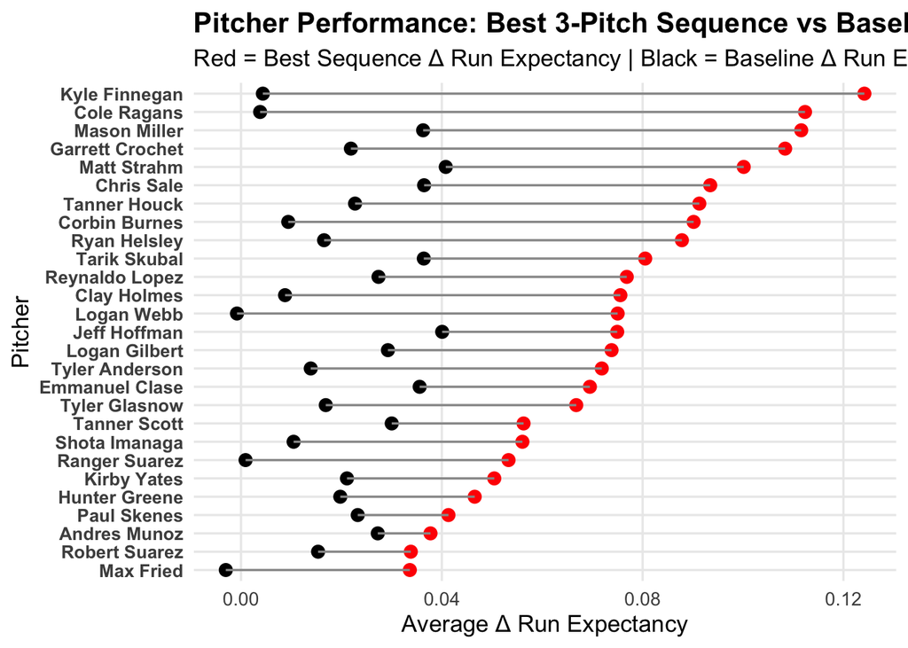

```r
ggplot(comparison_table, aes(x = reorder(Name, avg_delta_run_exp))) +
  geom_point(aes(y = baseline_avg_delta), color = "black", size = 3) +
  geom_point(aes(y = avg_delta_run_exp), color = "red", size = 3) +
  geom_segment(aes(xend = Name, y = baseline_avg_delta, yend = avg_delta_run_exp),
               color = "gray60", linewidth = 0.6) +
  coord_flip() +
  labs(
    title = "Pitcher Performance: Best 3-Pitch Sequence vs Baseline",
    subtitle = "Red = Best Sequence Δ Run Expectancy | Black = Baseline Δ Run Expectancy",
    x = "Pitcher",
    y = "Average Δ Run Expectancy"
  ) +
  theme_minimal(base_size = 13) +
  theme(
    panel.grid.minor = element_blank(),
    axis.text.y = element_text(face = "bold", size = 10),
    plot.title = element_text(face = "bold")
  )
```